# Assignment 1

In this assignment, we will be exploring the movement activity of a subject whose steps have been recorded for a period of two months, with measurements in buckets of 5-minutes intervals.

Importing steps dataset into R.

```r
data <- read.csv("activity.csv")
```

We first take a quick look at the dataset’s dimensions, variable names and see whether any missing values are present.

```r
dim(data)
```

```
## [1] 17568     3
```

```r
names(data)
```

```
## [1] "steps"    "date"     "interval"
```

```r
data$missingValues <- as.numeric(is.na(data$step))
sum(data$missingValues)
```

```
## [1] 2304
```

Our dataset consists of 17,568 observations, with three columns “Steps”, “Date” and “Interval” validating assignment guidelines.

The Dataset contains 2304 missing Values which correspond to around 13% of total observations

We first change the class of date from factor to Date format, to plot the data later as a time-series.

```r
data$date <- as.Date(data$date)
```

As per guidelines, we first plot the histogram of Steps per day

```r
library(dplyr)
```

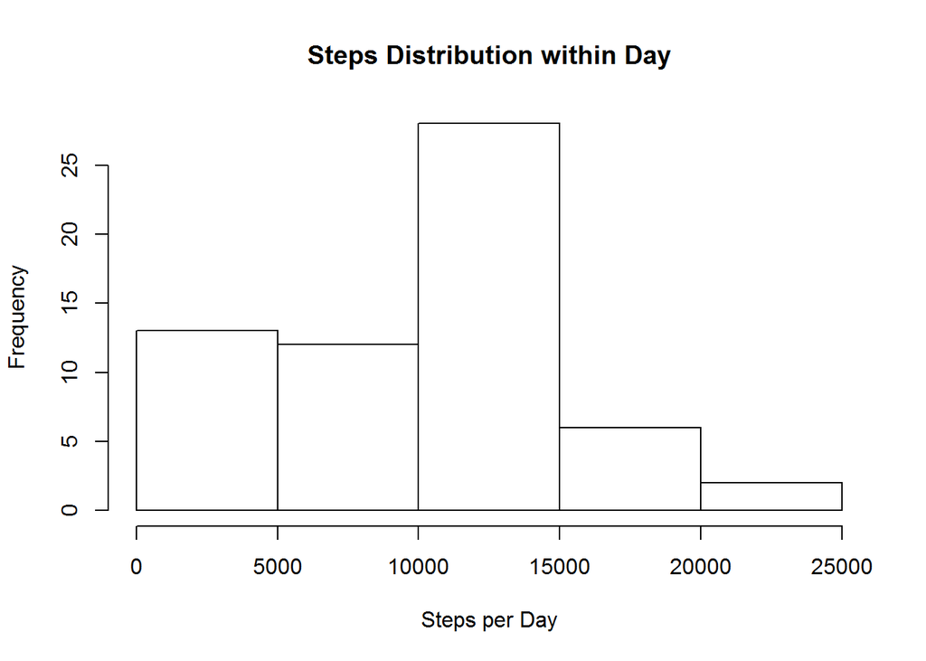

```r
dailytotal <- summarise(group_by(data,date), sum(steps, na.rm=T))
names(dailytotal) <- c("Date", "TotalSteps")
hist(dailytotal$TotalSteps, xlab ="Steps per Day", main ="Steps Distribution within Day")
```

We now turn to descriptive statistics to make better sense of how many steps are being taken every 5 minutes by the subject assessed.

```r
mean(dailytotal$TotalSteps)
```

```
## [1] 9354.23
```

```r
median(dailytotal$TotalSteps)
```

```
## [1] 10395
```

We now plot the time-Series for average steps taken in a given 5-Minute Interval within the day, averaged out across all similar interval in the dataset.

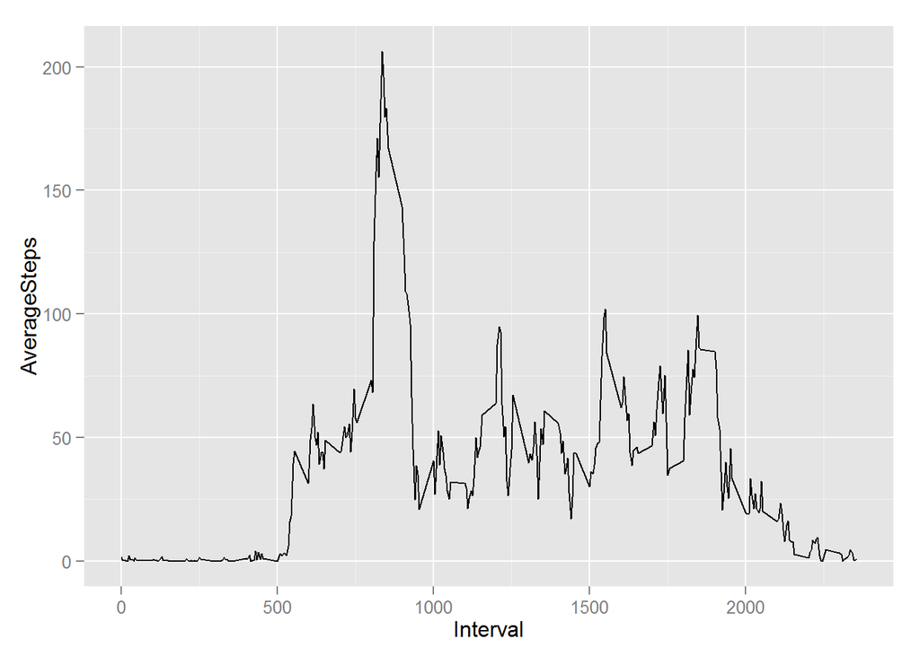

```r
library(dplyr)
library(ggplot2)
IntervalAverages <- summarise(group_by(data, interval), mean(steps, na.rm=T))
names(IntervalAverages) <- c("Interval", "AverageSteps")
IntAve <- ggplot(IntervalAverages,aes(Interval, AverageSteps))
IntAve + geom_line()
```

We can see that the interval during which the subject has taken the highest number of steps is the 835th interval, with an average of 206.2 steps.

We now turn to missing data imputation. We have already seen that 13% of observations are missing (2304 Obs), and we will consider using the Interval average across the two-months recording period as an imputation reference for all missing values.

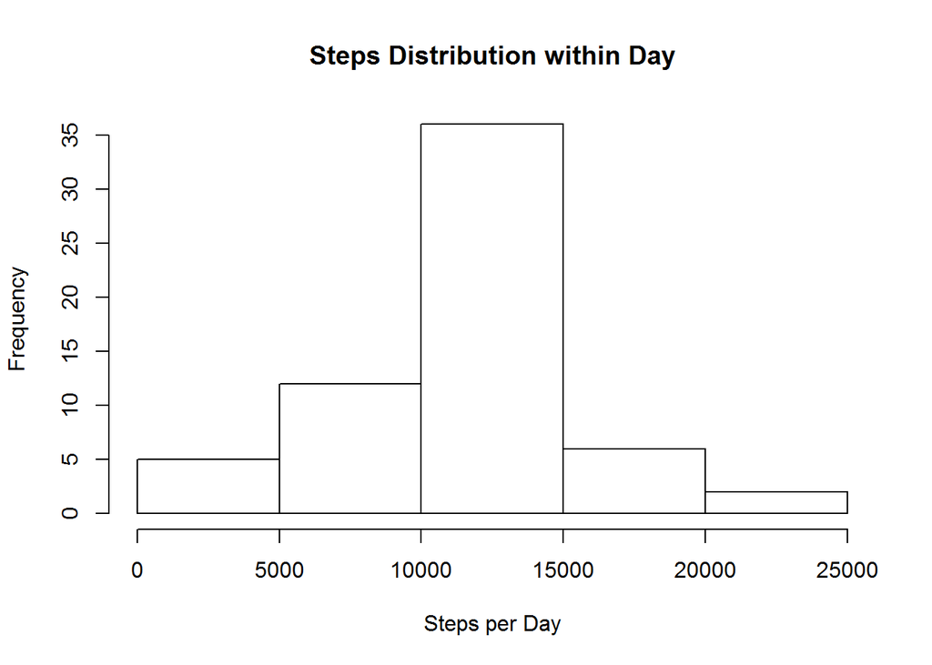

```r
library(dplyr)
#Indexing the Average Interval Value into the dataset if steps is missing
data2 <- merge(data, IntervalAverages, by.x="interval", by.y="Interval")
data2<- mutate(data2, ImputedSteps = ifelse(missingValues==1,AverageSteps,steps))
data2$steps <- NULL

#Create dataframe with total steps taken per day
dailytotal2 <- summarise(group_by(data2,date), sum(ImputedSteps))
names(dailytotal2) <- c("Date", "TotalSteps")
hist(dailytotal2$TotalSteps, xlab ="Steps per Day", main ="Steps Distribution within Day")
```

After plotting the imputed dataset, we observe a shift in centrality, through a reduction in skewness and a more central distribution.

To validate our previous claim we compute the mean and median of the imputed dataset.

```r
mean(dailytotal2$TotalSteps)
```

```
## [1] 10766.19
```

```r
median(dailytotal2$TotalSteps)
```

```
## [1] 10766.19
```

The new observed average is of 10766.19 steps per day, and the median corresponds now to the same value of 10766.19 steps. This validates our finding that the distribution has gained in centrality.

We will now explore the difference in movement patterns between weekends and weekdays.

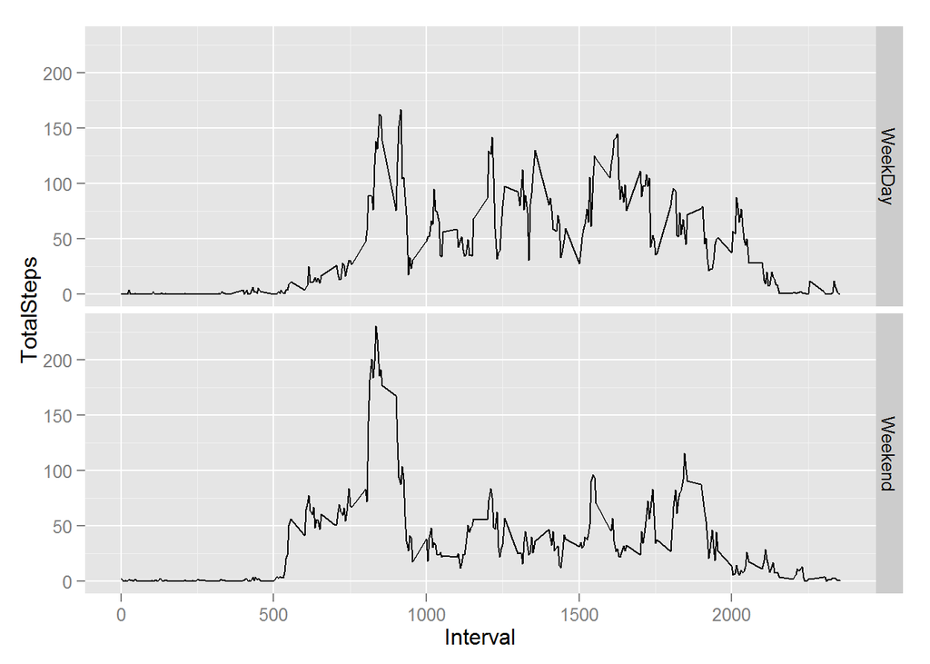

```r
library(dplyr)
library(ggplot2)
data2$day <- weekdays(data2$date)
weekend <- c("Saturday","Sunday")
data2 <- mutate(data2, WeekDay = ifelse(day %in% weekend, "WeekDay","Weekend"))
IntervalAverages2 <- summarise(group_by(data2,interval,WeekDay), mean(ImputedSteps))
names(IntervalAverages2) <- c("Interval", "Weekday","TotalSteps")
WeekdayDist <- ggplot(IntervalAverages2, aes(Interval, TotalSteps))
WeekdayDist + geom_line() + facet_grid(Weekday~.)
```